# R Notebook

## Section 2: Creating your own plots to explore trends (7 points)

1. Generate a set of plots that show how much sexual dimorphism there is in the four measurements of body size across the three species of penguins
- sex is a categorical variable and body size measurements are continuous
- so you’ll want something like a density plot or boxplot to compare distributions (refer to the R for Data Science section 2.5.1)
- facet_wrap() can be useful for viewing trends for different species (refer to the R for Data Science section 2.5.4)
- here you don’t need to format the axis or legend labels (unless you want to)

```r
library(ggplot2)
theme_set(theme_classic())
```

**Variable: culmen_length_mm**

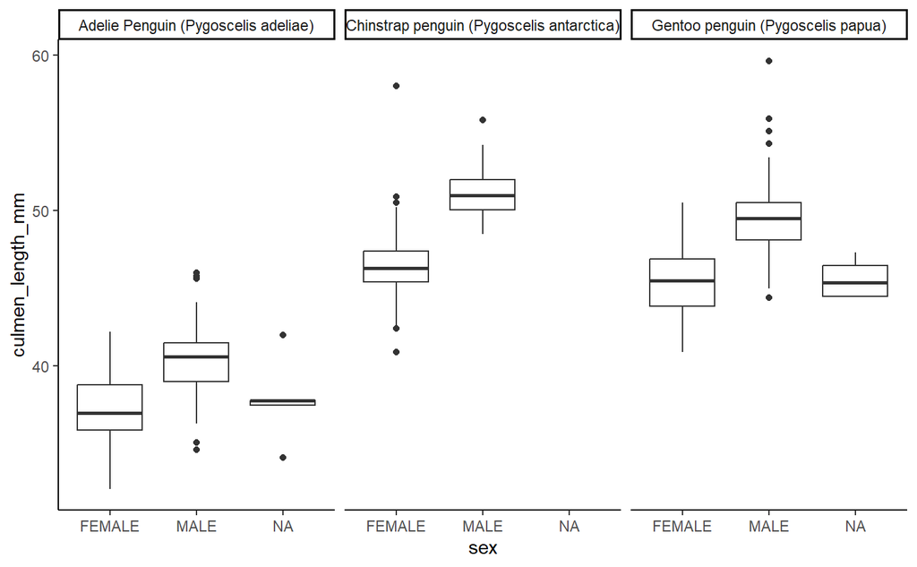

```r
cleaned_penguins %>%
  ggplot(aes(x = sex, y = culmen_length_mm)) +
  geom_boxplot() +
  facet_wrap(~species)
```

**Variable: culmen_depth_mm**

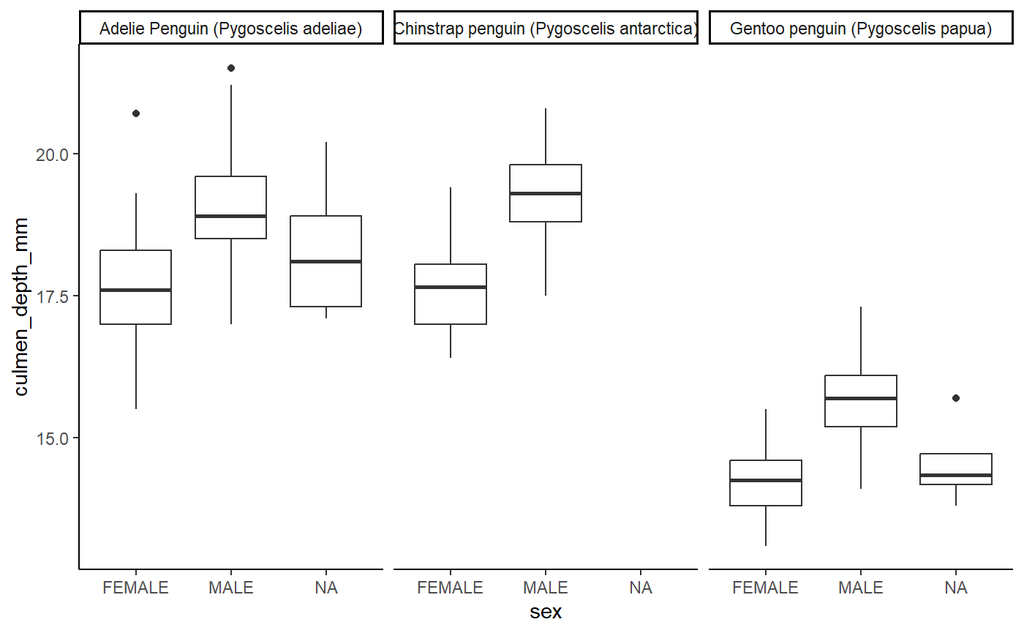

```r
cleaned_penguins %>%
  ggplot(aes(x = sex, y = culmen_depth_mm)) +
  geom_boxplot() +
  facet_wrap(~species)
```

**Variable: flipper_length_mm**

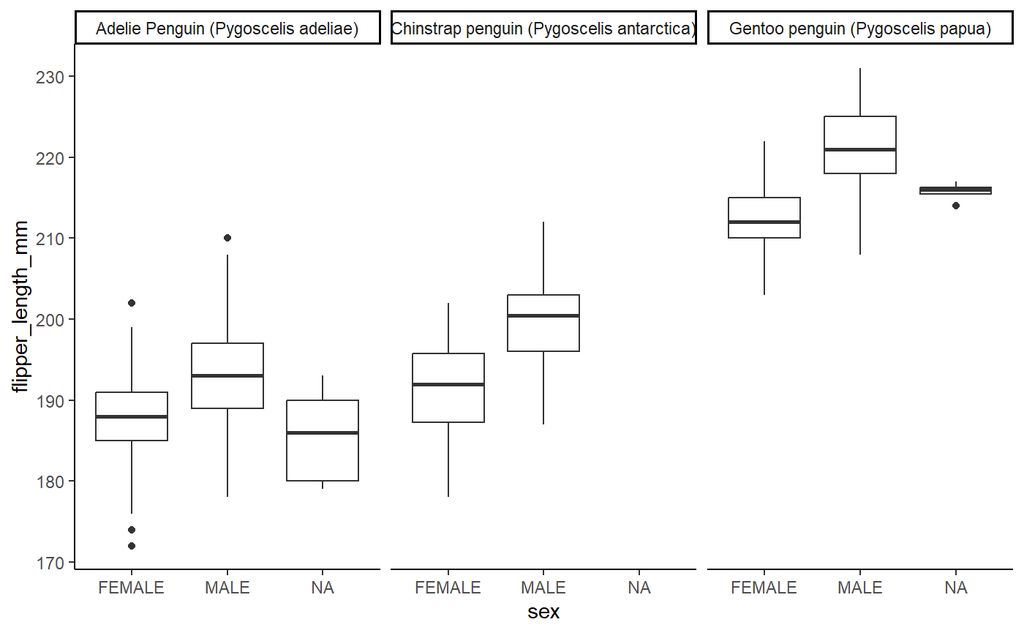

```r
cleaned_penguins %>%
  ggplot(aes(x = sex, y = flipper_length_mm)) +
  geom_boxplot() +
  facet_wrap(~species)
```

**Variable: body_mass_g**

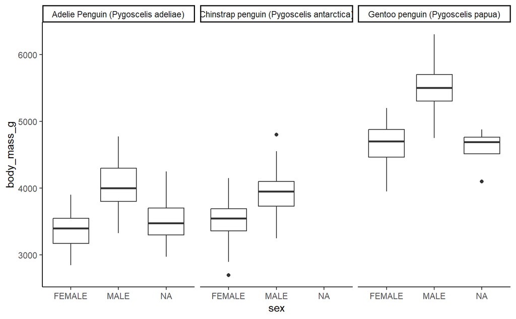

```r
cleaned_penguins %>%
  ggplot(aes(x = sex, y = body_mass_g)) +
  geom_boxplot() +
  facet_wrap(~species)
```

2. Generate another set of plots to show how much males and females differ in the two measurements of trophic niche (N and C ratios) across the three species
- I would recommend first making density/boxplots (refer to the R for Data Science section 2.5.1)
- then you can make scatterplots of C vs N ratios (refer to the R for Data Science section 2.2.4)
- in this case, year may be important because trophic niches tend to shift depending on food availability
- I would recommend separating years and species, and facet_grid(year~species) is one good way to accomplish that
- here you don’t need to format the axis or legend labels (unless you want to)

**Variable: delta_15_n_o_oo**

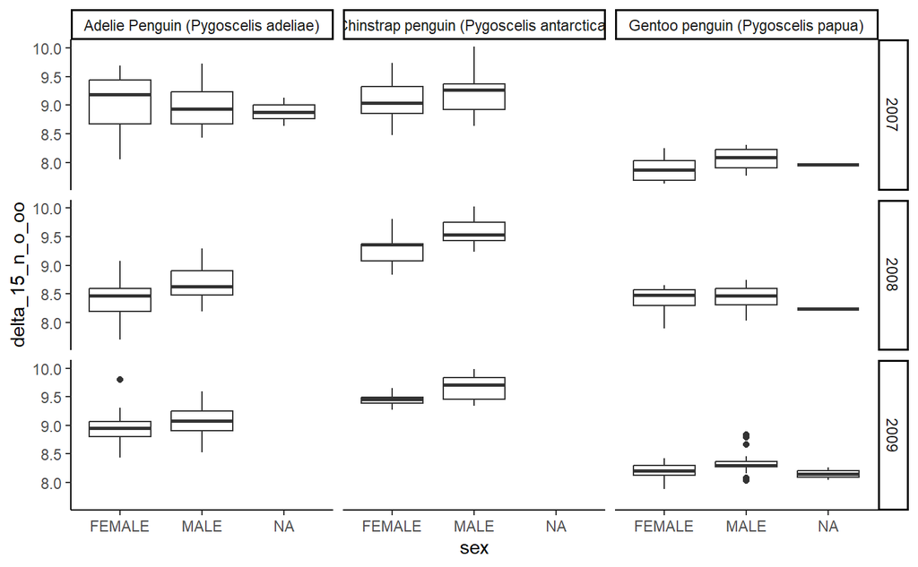

```r
# deriving the year from the date_egg variable
cleaned_penguins <- cleaned_penguins %>%
  mutate(year = substr(date_egg, 1, 4))

# box plots separated by year and species
cleaned_penguins %>%
  ggplot(aes(x = sex, y = delta_15_n_o_oo)) +
  geom_boxplot() +
  facet_grid(year~species)
```

**Variable: delta_13_c_o_oo**

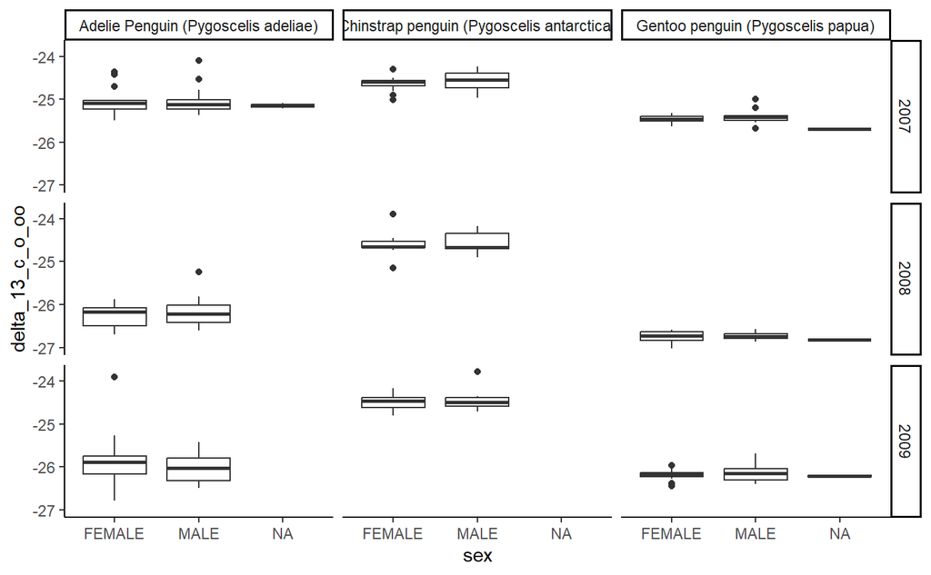

```r
# box plots separated by year and species
cleaned_penguins %>%
  ggplot(aes(x = sex, y = delta_13_c_o_oo)) +
  geom_boxplot() +
  facet_grid(year~species)
```

**Scatter Plots: delta_15_n_o_oo vs. delta_13_c_o_oo**

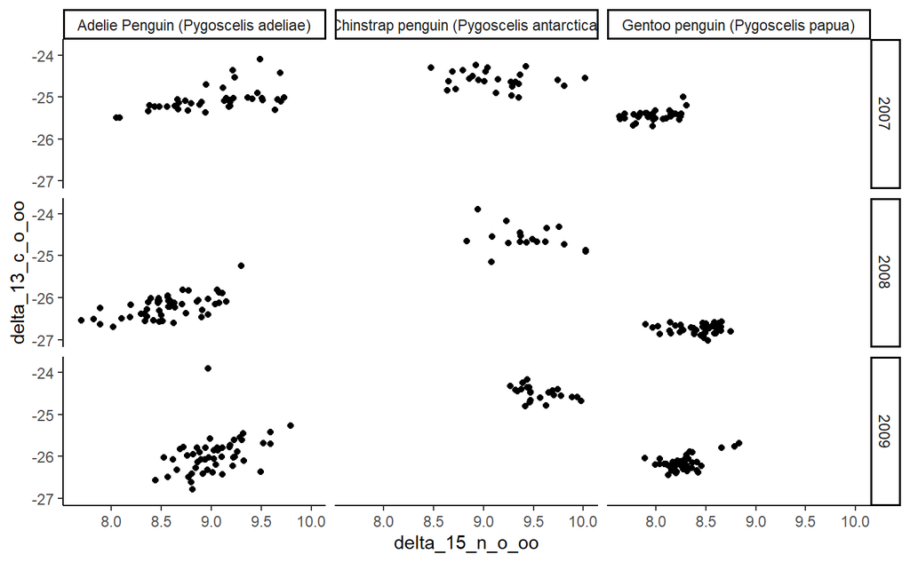

```r
# scatter plots faceted by year and species
cleaned_penguins %>%
  ggplot(aes(x = delta_15_n_o_oo, y = delta_13_c_o_oo)) +
  geom_point() +
  facet_grid(year~species)
```

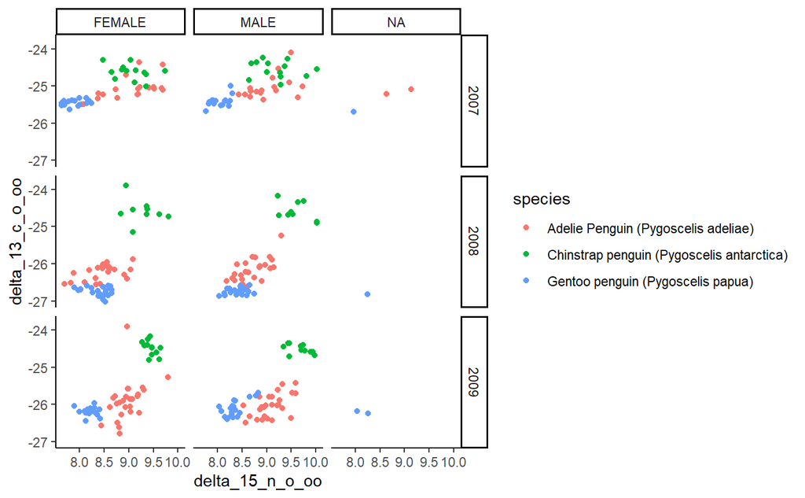

```r
# scatter plots faceted by sex and year (species is distinguished by color)
cleaned_penguins %>%
  ggplot(aes(x = delta_15_n_o_oo, y = delta_13_c_o_oo, color = species)) +
  geom_point() +
  facet_grid(year~sex)
```